# Лабоартороная работа №1

Операционные системы

Терещенкова М.В.

Российский университет дружбы народов, Москва, Россия

07 марта 2025

## Цель работы

Целью данной работы является приобретение практических навыков установки операционной системы на виртуальную машину, настройки минимально необходимых для дальнейшей работы сервисов.

## Задание

1. Создание виртуальной машины
2. Установка операционной системы
3. Работа с операционной системой после установки
4. Установка програмного обеспечения для создания документации

## Выполнение лабораторной работы

**Установка и создание виртуальной машины**

Нажимаю “Создать”, создаю новую виртуальную машину, указываю её имя, путь к папке машины оставляю по умолчанию,выбираю тип ОС и версию. Указываю объём основной памяти виртуальной машины размером 4096МБ. Создаю новый виртуальный жёсткий диск. Задаю размер диска - 80ГБ.

[figure not shown]

Создание виртуальной машины

## Выполнение лабораторной работы

**Установка операционной системы**

В терминале запускаю liveinst. Задаю имя компьютера **tereshchenkovamargo.net**. Создаю аккаунт админстратора и пароль для супер-пользователя.Создаю пользователя, добавляю административные привилегии для этой учетной записи, чтобы я могла свободно выполнять команды как супер-пользователь. Далее операционная система устанавливается.

[figure not shown]

Завершение установки операционной системы

## Выполнение лабораторной работы

**Работа с операционной системой после установки**

Запускаю терминал и переключаюсь на роль суперпользователя. Обновляю все пакеты.

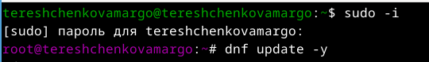

Обновления

## Выполнение лабораторной работы

Устанавливаю программы для удобства работы в консоли: tmux и mc

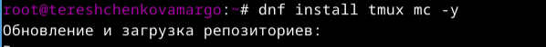

Установка tmux и mc

## Выполнение лабораторной работы

Примонтирую диск с помощью утилиты **mount**; устанавливаю драйвера.

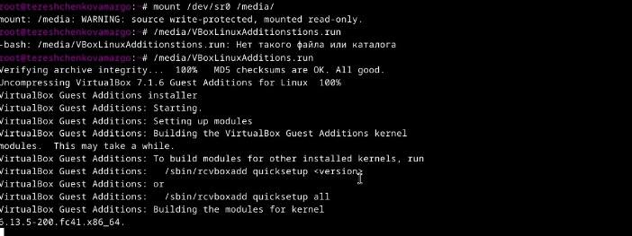

Примонтирование диска и установка драйвера

## Выполнение лабораторной работы

**Установка программного обеспечения для создания документации.**

Устанавливаю pandoc и pandoc-crossref вручную.

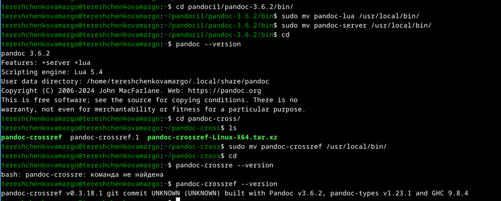

Успешная установка pandoc и pandoc-crossref

Устанавливаю дистрибутив texlive.

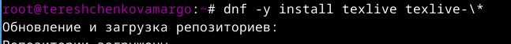

Установка texlive

## Выводы

Приобрела практические навыки установки операционной системы на виртуальную машину, настройки минимально необходимых для дальнейшей работы сервисов.

# Хорошего настроения!